# Completeness of adolescent births registration using DHS data: case of Benin

RamdaneOS

8/8/2020

# 1. Load 2011 and 2017 DHS datasets for Benin

The code will follow as much as possible the same nomenclature as that of the DHS. For example, “bj” is the code for Benin, “ir” is for women or individual dataset, “br” is for births, “pr” is for household members.

```r
#birth recode data

bjbr61fl <-
read_dta(
"/Users/ramoudaneorousannou/Downloads/BJ_2011-12_DHS_09012020_1317_141900/BJBR61DT/BJBR61FL.DTA")
#DHS 2011


bjbr71fl <-
read_dta("/Users/ramoudaneorousannou/Downloads/Dhs_data/BJBR71DT/BJBR71FL.DTA") # DHS 2017

#women recode data

bjir61fl <-
read_dta(
"/Users/ramoudaneorousannou/Downloads/BJ_2011-12_DHS_09012020_1317_141900/BJIR61DT/BJIR61FL.DTA")
#DHS 2011

bjir71fl <-
read_dta("/Users/ramoudaneorousannou/Downloads/Dhs_data/BJIR71DT/BJIR71FL.DTA") #DHS 2017


#household member recode data

bjpr61fl <-
read_dta(
"/Users/ramoudaneorousannou/Downloads/BJ_2011-12_DHS_09012020_1317_141900/BJPR61DT/BJPR61FL.DTA")
#DHS 2011

bjpr71fl <-
read_dta("/Users/ramoudaneorousannou/Downloads/Dhs_data/BJPR71DT/BJPR71FL.DTA") #DHS 2017
```

# 2. Data.Prepare function

This function takes selected variables from the DHS Births, Women and Household Members datasets and merge them into one dataset and calculate agegroup_5, agegroup_10 and the weight variables.

```r
Data.Prepare <- function(Birth, Women, HouseholdM) {

  # select variables needed from the Births dataset

  Birth <-
  Birth %>%
  select("v001", "v002", "v003", "b3", "b16", "v008")
  # create a matching variable for merging
  Birth$matching <- paste(Birth$v001, Birth$v002, Birth$v003, sep = "-")

  # select variables needed from the Women dataset
  Women <-
  Women %>%
  select("v001", "v002", "v003", "v011")

  # create a matching variable for merging
  Women$matching <- paste(Women$v001, Women$v002, Women$v003, sep = "-")

  # merging children to their mothers (births to women)

  brir <- Birth %>%
  left_join(Women, by = "matching")


  brir <- brir %>%
  select("v001.x", "v002.x", "v003.x", "b3", "b16", "v008", "v011")

  # create a new matching variable for merging
  brir$matching <-
  paste(brir$v001.x, brir$v002.x, brir$b16, sep = "-")

  # select variables needed from the Household members dataset

  HouseholdM <-
  HouseholdM %>%
  select("hv001", "hv002", "hvidx", "hv005", "hv021", "hv023",
           "hv024", "hv102", "hv105", "hv140")

  # create a matching variable for merging
  HouseholdM$matching <-
  paste(HouseholdM$hv001, HouseholdM$hv002, HouseholdM$hvidx, sep = "-")

  # Merging children and their mothers data to the household data

  brirpr <- brir %>%
  inner_join(HouseholdM, by = "matching")

  # calculate age groups
  brirpr <- brirpr %>%
  mutate(agegroup = round((b3 - v011)/60))


  # creating "birth_cert" variable for de jure children under age 5
  # whose births are registered and who had a birth certificate

  brirpr$birth_cert <- ifelse(brirpr$hv140 == 1, 1, 0)

  # creating "birth_reg" variable for de jure children under age 5
  # whose births are registered

  brirpr$birth_reg <- ifelse(brirpr$hv140 == 1 | brirpr$hv140 == 2, 1, 0)

  # Creating weight variable
  brirpr$wt <- brirpr$hv005/1000000

  # replacing values assigned to each region by labels
  brirpr$hv024 <- as_label(brirpr$hv024)

  # replacing age groups by 5 years agegroup labels
  brirpr <- brirpr %>%
  filter(agegroup %in% 3:10) %>%
  mutate(agegroup_5 =   ifelse(agegroup == 3, "15-19",
                        ifelse(agegroup == 4, "20-24",
                        ifelse(agegroup == 5, "25-29",
                        ifelse(agegroup == 6, "30-34",
                        ifelse(agegroup == 7, "35-39",
                        ifelse(agegroup == 8, "40-44",
                        ifelse(agegroup == 9, "45-49",
                        ifelse(agegroup == 10, "49-53", " ")))))))))

  # replacing age groups by 10 years agegroup labels
  brirpr <- brirpr %>%
  filter(agegroup %in% 3:10) %>%
  mutate(agegroup_10 =   ifelse(agegroup %in% 3:4, "15-24",
                         ifelse(agegroup %in% 5:6, "25-34",
                         ifelse(agegroup %in% 7:8, "35-44",
                         ifelse(agegroup %in% 9:10, "45-53", " ")))))

  return(brirpr)

}
```

```r
# Transform 2011 datasets
bjbrirpr61fl <- Data.Prepare(Birth = bjbr61fl, Women = bjir61fl, HouseholdM = bjpr61fl)

# Transform 2017 datasets
bjbrirpr71fl <- Data.Prepare(Birth = bjbr71fl, Women = bjir71fl, HouseholdM = bjpr71fl)
```

# 3. Birth registration completeness by age group of mothers

## 3.1.U5BCOR function

Function U5BCOR for children under 5 years of age who have a birth certificate or are registered is a function which calculates the indicator according to different scenarios. The function takes three arguments:

- **data** argument, output from previous Data.Prepare function,
- **var1** argument, specify the indicator you want to compute (birth_cert for birth certificate possession, or birth_reg for birth registration completeness),
- **var2** argument, specify grouping variable (national or by region or by agegroup_5 or agegroup_10, etc.). In case this argument is not specified, the function will compute the indicator at subnational level.

```r
# U5BCOR for "Children Under age 5 Who have Birth Certificate or are Registered"
# is a function that calculate the indicator under various scenario

U5BCOR <- function(data, var1, var2 = NULL, caption) {
require(dplyr)

if(is.null(var2)) {
var2 <- data$hv024

# Complex sample design parameters
DHSdesign <- survey::svydesign(ids = ~hv021, strata = ~hv023,
                       weights = ~wt, data = data)

# tabulate indicator "children under age 5 who have birth certificate or registered"

birth_cert_or_reg <-
survey::svyby(formula = var1, by = var2, DHSdesign, svymean, na.rm =  TRUE,
                              vartype = c("se","ci"))

table_U5BC <-
birth_cert_or_reg %>%
rename(Region = by) %>%
kable(format = "pipe", caption = caption, row.names = FALSE)
return(table_U5BC)
} else {

# Complex sample design parameters
DHSdesign <- survey::svydesign(ids = ~hv021, strata = ~hv023,
                       weights = ~wt, data = data)

# tabulate indicator "children under age 5 who have birth certificate or registered"

birth_cert_or_reg <-
survey::svyby(formula = var1, by = var2, DHSdesign, svymean, na.rm =  TRUE,
                              vartype = c("se","ci"))

if (any(names(birth_cert_or_reg) == "hv024")) {
table_U5BC <-
rename(birth_cert_or_reg, Region = hv024)
table_U5BC <-
kable(table_U5BC, format = "pipe", caption = caption, row.names = FALSE)
} else {
table_U5BC <-
kable(birth_cert_or_reg, format = "pipe", caption = caption, row.names = FALSE)}

if(any(names(birth_cert_or_reg)) %in% c("birth_cert", "birth_reg", "hv024", "agegroup_5",  "agegroup_10", "se", "ci_l", "ci_u")) {

birth_cert_or_reg$Birth_Cert <- paste(birth_cert_or_reg$birth_cert)
birth_cert_or_reg$Birth_Reg  <- paste(birth_cert_or_reg$birth_reg)
birth_cert_or_reg$Region     <- paste(birth_cert_or_reg$hv024)
birth_cert_or_reg$Age_Group  <- paste(birth_cert_or_reg$agegroup_5)
birth_cert_or_reg$Age_Group  <- paste(birth_cert_or_reg$agegroup_10)
birth_cert_or_reg$SE         <- paste(birth_cert_or_reg$se)
birth_cert_or_reg$CI_L       <- paste(birth_cert_or_reg$ci_l)
birth_cert_or_reg$CI_U       <- paste(birth_cert_or_reg$ci_u)}   else {

table_U5BC <-
kable(birth_cert_or_reg, format = "pipe", caption = caption, row.names = FALSE)}


return(table_U5BC)
}
}
```

```r
U5BCOR(data = bjbrirpr61fl, var1 = ~birth_cert, caption = "Children under age 5
         who have birth certificate by region (DHS 2011)")
```

Children under age 5 who have birth certificate by region (DHS 2011)

| Region | birth_cert | se | ci_l | ci_u |
| --- | --- | --- | --- | --- |
| Alibori | 0.3908622 | 0.0475276 | 0.2977098 | 0.4840146 |
| Atacora | 0.5517300 | 0.0264898 | 0.4998109 | 0.6036490 |
| Atlantique | 0.7309789 | 0.0169912 | 0.6976767 | 0.7642811 |
| Borgou | 0.5624809 | 0.0365314 | 0.4908807 | 0.6340811 |
| Collines | 0.5704373 | 0.0368749 | 0.4981638 | 0.6427107 |
| Couffo | 0.4927586 | 0.0318405 | 0.4303524 | 0.5551648 |
| Donga | 0.6792321 | 0.0397163 | 0.6013895 | 0.7570746 |
| Littoral | 0.7859530 | 0.0181873 | 0.7503065 | 0.8215995 |
| Mono | 0.6274616 | 0.0334705 | 0.5618606 | 0.6930625 |
| Ouémé | 0.6945417 | 0.0230815 | 0.6493029 | 0.7397806 |
| Plateau | 0.6160497 | 0.0587618 | 0.5008788 | 0.7312207 |
| Zou | 0.5996116 | 0.0234175 | 0.5537140 | 0.6455091 |

```r
U5BCOR(data = bjbrirpr71fl, var1 = ~birth_cert, caption = "Children under age 5
         who have birth certificate by region (DHS 2017)")
```

Children under age 5 who have birth certificate by region (DHS 2017)

| Region | birth_cert | se | ci_l | ci_u |
| --- | --- | --- | --- | --- |
| alibori | 0.5310796 | 0.0419395 | 0.4488796 | 0.6132795 |
| atacora | 0.6682540 | 0.0243440 | 0.6205407 | 0.7159672 |
| atlantic | 0.7305354 | 0.0202672 | 0.6908125 | 0.7702584 |
| borgou | 0.4559437 | 0.0392138 | 0.3790860 | 0.5328014 |
| collines | 0.6885272 | 0.0348169 | 0.6202873 | 0.7567672 |
| couffo | 0.6573737 | 0.0261760 | 0.6060696 | 0.7086777 |
| donga | 0.7994443 | 0.0398490 | 0.7213418 | 0.8775469 |
| littoral | 0.8261413 | 0.0238621 | 0.7793725 | 0.8729102 |
| mono | 0.6367286 | 0.0390854 | 0.5601227 | 0.7133346 |
| ouémé | 0.6076443 | 0.0259519 | 0.5567796 | 0.6585090 |
| plateau | 0.6303088 | 0.0341984 | 0.5632812 | 0.6973363 |
| zou | 0.7333415 | 0.0284462 | 0.6775880 | 0.7890949 |

```r
U5BCOR(data = bjbrirpr61fl, var1 = ~birth_reg,
       caption = "Children under age 5 who are registered by region (DHS 2011)")
```

Children under age 5 who are registered by region (DHS 2011)

| Region | birth_reg | se | ci_l | ci_u |
| --- | --- | --- | --- | --- |
| Alibori | 0.4449166 | 0.0483416 | 0.3501687 | 0.5396644 |
| Atacora | 0.7439482 | 0.0230067 | 0.6988559 | 0.7890406 |
| Atlantique | 0.8998060 | 0.0110536 | 0.8781414 | 0.9214706 |
| Borgou | 0.6767048 | 0.0348444 | 0.6084110 | 0.7449985 |
| Collines | 0.8656251 | 0.0361159 | 0.7948393 | 0.9364108 |
| Couffo | 0.7789573 | 0.0250783 | 0.7298048 | 0.8281098 |
| Donga | 0.8221274 | 0.0370837 | 0.7494448 | 0.8948100 |
| Littoral | 0.9534860 | 0.0090731 | 0.9357031 | 0.9712689 |
| Mono | 0.9135105 | 0.0187512 | 0.8767588 | 0.9502621 |
| Ouémé | 0.8929424 | 0.0109984 | 0.8713859 | 0.9144988 |
| Plateau | 0.7880957 | 0.0531148 | 0.6839926 | 0.8921987 |
| Zou | 0.8297277 | 0.0151036 | 0.8001252 | 0.8593302 |

```r
U5BCOR(data = bjbrirpr71fl, var1 = ~birth_reg,
       caption = "Children under age 5 who are registered by region (DHS 2017)")
```

Children under age 5 who are registered by region (DHS 2017)

| Region | birth_reg | se | ci_l | ci_u |
| --- | --- | --- | --- | --- |
| alibori | 0.8416292 | 0.0263986 | 0.7898889 | 0.8933695 |
| atacora | 0.8288797 | 0.0251295 | 0.7796269 | 0.8781326 |
| atlantic | 0.9297016 | 0.0124889 | 0.9052238 | 0.9541793 |
| borgou | 0.6607317 | 0.0393577 | 0.5835920 | 0.7378714 |
| collines | 0.8987583 | 0.0210534 | 0.8574944 | 0.9400223 |
| couffo | 0.8593493 | 0.0191334 | 0.8218485 | 0.8968501 |
| donga | 0.9017019 | 0.0288180 | 0.8452197 | 0.9581841 |
| littoral | 0.9461028 | 0.0120422 | 0.9225004 | 0.9697051 |
| mono | 0.9514131 | 0.0119940 | 0.9279053 | 0.9749209 |
| ouémé | 0.9071639 | 0.0120097 | 0.8836253 | 0.9307026 |
| plateau | 0.8967087 | 0.0183597 | 0.8607244 | 0.9326930 |
| zou | 0.9696466 | 0.0060645 | 0.9577604 | 0.9815328 |

```r
# tabulate indicator "children under age 5 who have birth certificate"
# by 5-year agegroup of mother at national level

U5BCOR(data = bjbrirpr71fl, var1 = ~birth_cert , var2 = ~agegroup_5,
       caption = "Children under age 5
         who have birth certificate by 5-year agegroup of mother at national level (DHS 2017)")
```

Children under age 5 who have birth certificate by 5-year agegroup of mother at national level (DHS 2017)

| agegroup_5 | birth_cert | se | ci_l | ci_u |
| --- | --- | --- | --- | --- |
| 15-19 | 0.5520624 | 0.0308327 | 0.4916314 | 0.6124934 |
| 20-24 | 0.6223214 | 0.0154713 | 0.5919982 | 0.6526446 |
| 25-29 | 0.6588130 | 0.0134385 | 0.6324740 | 0.6851520 |
| 30-34 | 0.6471167 | 0.0147896 | 0.6181296 | 0.6761038 |
| 35-39 | 0.6707504 | 0.0152034 | 0.6409524 | 0.7005485 |
| 40-44 | 0.5912855 | 0.0218163 | 0.5485264 | 0.6340446 |
| 45-49 | 0.6264122 | 0.0367027 | 0.5544761 | 0.6983482 |
| 49-53 | 0.3875772 | 0.1869189 | 0.0212229 | 0.7539315 |

```r
# tabulate indicator "children under age 5 who have birth certificate"
# by 10 years agegroup of mother at national level

U5BCOR(data = bjbrirpr71fl, var1 = ~birth_cert , var2 = ~agegroup_10,
       caption = "Children under age 5
         who have birth certificate by 10-year agegroup of mother at national level (DHS 2017)")
```

Children under age 5 who have birth certificate by 10-year agegroup of mother at national level (DHS 2017)

| agegroup_10 | birth_cert | se | ci_l | ci_u |
| --- | --- | --- | --- | --- |
| 15-24 | 0.6138593 | 0.0151611 | 0.5841440 | 0.6435745 |
| 25-34 | 0.6537677 | 0.0120144 | 0.6302199 | 0.6773155 |
| 35-44 | 0.6463087 | 0.0145217 | 0.6178467 | 0.6747706 |
| 45-53 | 0.6195501 | 0.0373023 | 0.5464389 | 0.6926614 |

```r
# tabulate indicator "children under age 5 who have birth certificate" by region
# and agegroup of mother


U5BCOR(data = bjbrirpr71fl, var1 = ~birth_cert , var2 = ~hv024+agegroup_5,
       caption =  "Children under age 5
         who have birth certificate by region and 5-year agegroup of mother (DHS 2017)")
```

Children under age 5 who have birth certificate by region and 5-year agegroup of mother (DHS 2017)

| hv024 | agegroup_5 | birth_cert | se | ci_l | ci_u |
| --- | --- | --- | --- | --- | --- |
| alibori | 15-19 | 0.5200105 | 0.0626841 | 0.3971519 | 0.6428691 |
| atacora | 15-19 | 0.7473417 | 0.0757118 | 0.5989492 | 0.8957341 |
| atlantic | 15-19 | 0.6792995 | 0.1509065 | 0.3835282 | 0.9750708 |
| borgou | 15-19 | 0.2971743 | 0.0615092 | 0.1766186 | 0.4177301 |
| collines | 15-19 | 0.6421977 | 0.0553916 | 0.5336321 | 0.7507633 |
| couffo | 15-19 | 0.7145846 | 0.1204024 | 0.4786003 | 0.9505688 |
| donga | 15-19 | 0.8379397 | 0.0706642 | 0.6994405 | 0.9764390 |
| littoral | 15-19 | 0.6015399 | 0.1420742 | 0.3230795 | 0.8800003 |
| mono | 15-19 | 0.4624704 | 0.1269937 | 0.2135673 | 0.7113734 |
| ouémé | 15-19 | 0.7455496 | 0.1796342 | 0.3934731 | 1.0976261 |
| plateau | 15-19 | 0.0000000 | 0.0000000 | 0.0000000 | 0.0000000 |
| zou | 15-19 | 0.6551717 | 0.0988425 | 0.4614439 | 0.8488995 |
| alibori | 20-24 | 0.4782201 | 0.0461671 | 0.3877344 | 0.5687059 |
| atacora | 20-24 | 0.7225800 | 0.0337808 | 0.6563708 | 0.7887893 |
| atlantic | 20-24 | 0.7250435 | 0.0345936 | 0.6572413 | 0.7928457 |
| borgou | 20-24 | 0.4496147 | 0.0474715 | 0.3565722 | 0.5426572 |
| collines | 20-24 | 0.7147823 | 0.0403795 | 0.6356399 | 0.7939247 |
| couffo | 20-24 | 0.6784096 | 0.0441636 | 0.5918505 | 0.7649686 |
| donga | 20-24 | 0.8183049 | 0.0484637 | 0.7233177 | 0.9132920 |
| littoral | 20-24 | 0.7399542 | 0.0421336 | 0.6573738 | 0.8225346 |
| mono | 20-24 | 0.6078015 | 0.0551951 | 0.4996212 | 0.7159818 |
| ouémé | 20-24 | 0.5743113 | 0.0425266 | 0.4909607 | 0.6576620 |
| plateau | 20-24 | 0.5751128 | 0.0529680 | 0.4712973 | 0.6789282 |
| zou | 20-24 | 0.7287025 | 0.0411995 | 0.6479529 | 0.8094521 |
| alibori | 25-29 | 0.5419853 | 0.0507105 | 0.4425945 | 0.6413761 |
| atacora | 25-29 | 0.6479657 | 0.0378330 | 0.5738145 | 0.7221169 |
| atlantic | 25-29 | 0.7811957 | 0.0262694 | 0.7297087 | 0.8326828 |
| borgou | 25-29 | 0.4607005 | 0.0435069 | 0.3754287 | 0.5459724 |
| collines | 25-29 | 0.6727892 | 0.0487306 | 0.5772789 | 0.7682995 |
| couffo | 25-29 | 0.7242276 | 0.0355126 | 0.6546242 | 0.7938310 |

[output cut: 60 more lines]

```r
# tabulate indicator "children under age 5 who have birth certificate" by region
# and 10 years agegroup of mother

U5BCOR(data = bjbrirpr71fl, var1 = ~birth_cert , var2 = ~hv024+agegroup_10,
       caption =  "Children under age 5
         who have birth certificate by region and 10-year agegroup of mother (DHS 2017)")
```

Children under age 5 who have birth certificate by region and 10-year agegroup of mother (DHS 2017)

| hv024 | agegroup_10 | birth_cert | se | ci_l | ci_u |
| --- | --- | --- | --- | --- | --- |
| alibori | 15-24 | 0.4854133 | 0.0420756 | 0.4029466 | 0.5678800 |
| atacora | 15-24 | 0.7263788 | 0.0330310 | 0.6616393 | 0.7911184 |
| atlantic | 15-24 | 0.7209359 | 0.0369198 | 0.6485745 | 0.7932974 |
| borgou | 15-24 | 0.4260459 | 0.0452784 | 0.3373019 | 0.5147900 |
| collines | 15-24 | 0.7045781 | 0.0370457 | 0.6319699 | 0.7771863 |
| couffo | 15-24 | 0.6809076 | 0.0421618 | 0.5982721 | 0.7635432 |
| donga | 15-24 | 0.8203901 | 0.0483971 | 0.7255335 | 0.9152467 |
| littoral | 15-24 | 0.7283159 | 0.0413517 | 0.6472681 | 0.8093636 |
| mono | 15-24 | 0.5890132 | 0.0555673 | 0.4801034 | 0.6979230 |
| ouémé | 15-24 | 0.5826548 | 0.0433728 | 0.4976456 | 0.6676640 |
| plateau | 15-24 | 0.5376724 | 0.0539103 | 0.4320101 | 0.6433346 |
| zou | 15-24 | 0.7235735 | 0.0394021 | 0.6463467 | 0.8008003 |
| alibori | 25-34 | 0.5480321 | 0.0489985 | 0.4519968 | 0.6440673 |
| atacora | 25-34 | 0.6393896 | 0.0288420 | 0.5828603 | 0.6959189 |
| atlantic | 25-34 | 0.7509392 | 0.0221627 | 0.7075011 | 0.7943774 |
| borgou | 25-34 | 0.4540130 | 0.0417732 | 0.3721390 | 0.5358870 |
| collines | 25-34 | 0.6746439 | 0.0455633 | 0.5853413 | 0.7639464 |
| couffo | 25-34 | 0.6890329 | 0.0350682 | 0.6203005 | 0.7577653 |
| donga | 25-34 | 0.8021866 | 0.0373316 | 0.7290181 | 0.8753551 |
| littoral | 25-34 | 0.8442911 | 0.0251891 | 0.7949215 | 0.8936608 |
| mono | 25-34 | 0.6590512 | 0.0422162 | 0.5763089 | 0.7417936 |
| ouémé | 25-34 | 0.6182679 | 0.0261314 | 0.5670513 | 0.6694844 |
| plateau | 25-34 | 0.6701672 | 0.0374542 | 0.5967585 | 0.7435760 |
| zou | 25-34 | 0.7450237 | 0.0293597 | 0.6874799 | 0.8025676 |
| alibori | 35-44 | 0.5632712 | 0.0486347 | 0.4679489 | 0.6585935 |
| atacora | 35-44 | 0.6581809 | 0.0441898 | 0.5715705 | 0.7447913 |
| atlantic | 35-44 | 0.6897449 | 0.0377988 | 0.6156607 | 0.7638292 |
| borgou | 35-44 | 0.4986230 | 0.0508660 | 0.3989275 | 0.5983186 |
| collines | 35-44 | 0.7058334 | 0.0464228 | 0.6148465 | 0.7968204 |
| couffo | 35-44 | 0.5779393 | 0.0513500 | 0.4772953 | 0.6785834 |
| donga | 35-44 | 0.7733674 | 0.0533927 | 0.6687197 | 0.8780151 |
| littoral | 35-44 | 0.8453777 | 0.0397471 | 0.7674748 | 0.9232806 |
| mono | 35-44 | 0.6523177 | 0.0541009 | 0.5462820 | 0.7583535 |
| ouémé | 35-44 | 0.6032601 | 0.0524007 | 0.5005566 | 0.7059637 |
| plateau | 35-44 | 0.6138518 | 0.0527079 | 0.5105462 | 0.7171575 |
| zou | 35-44 | 0.7120847 | 0.0409049 | 0.6319127 | 0.7922567 |
| alibori | 45-53 | 0.6669128 | 0.1260026 | 0.4199522 | 0.9138733 |
| atacora | 45-53 | 0.6178228 | 0.0792283 | 0.4625382 | 0.7731074 |
| atlantic | 45-53 | 0.6596191 | 0.1203814 | 0.4236759 | 0.8955623 |
| borgou | 45-53 | 0.6601223 | 0.1157572 | 0.4332423 | 0.8870024 |
| collines | 45-53 | 0.6167893 | 0.1114154 | 0.3984191 | 0.8351594 |
| couffo | 45-53 | 0.5111399 | 0.1096161 | 0.2962963 | 0.7259835 |
| donga | 45-53 | 0.7486383 | 0.1452098 | 0.4640323 | 1.0332443 |
| littoral | 45-53 | 1.0000000 | 0.0000000 | 1.0000000 | 1.0000000 |
| mono | 45-53 | 0.4625996 | 0.1541077 | 0.1605540 | 0.7646452 |
| ouémé | 45-53 | 0.5273029 | 0.2034383 | 0.1285711 | 0.9260346 |
| plateau | 45-53 | 0.4107004 | 0.1391362 | 0.1379985 | 0.6834022 |
| zou | 45-53 | 0.7592794 | 0.1097357 | 0.5442014 | 0.9743575 |

```r
# tabulate indicator "children under age 5 who are registered"
# by 10 years agegroup of mother at national level

U5BCOR(data = bjbrirpr71fl, var1 = ~birth_reg , var2 = ~hv024+agegroup_10,
       caption =  "Birth registration completeness
      by 10-year agegroup of mother (DHS 2017)")
```

Birth registration completeness by 10-year agegroup of mother (DHS 2017)

| hv024 | agegroup_10 | birth_reg | se | ci_l | ci_u |
| --- | --- | --- | --- | --- | --- |
| alibori | 15-24 | 0.8565081 | 0.0269720 | 0.8036440 | 0.9093723 |
| atacora | 15-24 | 0.8542856 | 0.0288396 | 0.7977610 | 0.9108101 |
| atlantic | 15-24 | 0.9293174 | 0.0211627 | 0.8878392 | 0.9707956 |
| borgou | 15-24 | 0.6759853 | 0.0406892 | 0.5962360 | 0.7557346 |
| collines | 15-24 | 0.9177850 | 0.0211831 | 0.8762668 | 0.9593032 |
| couffo | 15-24 | 0.8520334 | 0.0330168 | 0.7873217 | 0.9167452 |
| donga | 15-24 | 0.9218232 | 0.0292272 | 0.8645391 | 0.9791074 |
| littoral | 15-24 | 0.8956351 | 0.0352772 | 0.8264931 | 0.9647771 |
| mono | 15-24 | 0.9366321 | 0.0212458 | 0.8949910 | 0.9782731 |
| ouémé | 15-24 | 0.8765260 | 0.0237095 | 0.8300561 | 0.9229958 |
| plateau | 15-24 | 0.9061901 | 0.0254657 | 0.8562782 | 0.9561019 |
| zou | 15-24 | 0.9674796 | 0.0121596 | 0.9436472 | 0.9913121 |
| alibori | 25-34 | 0.8376791 | 0.0277554 | 0.7832795 | 0.8920788 |
| atacora | 25-34 | 0.8034678 | 0.0299595 | 0.7447484 | 0.8621873 |
| atlantic | 25-34 | 0.9288732 | 0.0150959 | 0.8992858 | 0.9584606 |
| borgou | 25-34 | 0.6418873 | 0.0450592 | 0.5535729 | 0.7302017 |
| collines | 25-34 | 0.8847950 | 0.0247387 | 0.8363081 | 0.9332819 |
| couffo | 25-34 | 0.8633784 | 0.0241895 | 0.8159679 | 0.9107888 |
| donga | 25-34 | 0.9166892 | 0.0279380 | 0.8619316 | 0.9714467 |
| littoral | 25-34 | 0.9632943 | 0.0100569 | 0.9435830 | 0.9830055 |
| mono | 25-34 | 0.9635081 | 0.0146633 | 0.9347687 | 0.9922476 |
| ouémé | 25-34 | 0.9200418 | 0.0137259 | 0.8931396 | 0.9469440 |
| plateau | 25-34 | 0.9105791 | 0.0192488 | 0.8728522 | 0.9483060 |
| zou | 25-34 | 0.9743191 | 0.0070686 | 0.9604648 | 0.9881734 |
| alibori | 35-44 | 0.8190302 | 0.0439104 | 0.7329674 | 0.9050929 |
| atacora | 35-44 | 0.8343715 | 0.0298738 | 0.7758200 | 0.8929230 |
| atlantic | 35-44 | 0.9283095 | 0.0176637 | 0.8936894 | 0.9629297 |
| borgou | 35-44 | 0.6785742 | 0.0450122 | 0.5903519 | 0.7667965 |
| collines | 35-44 | 0.9134427 | 0.0344804 | 0.8458623 | 0.9810231 |
| couffo | 35-44 | 0.8539075 | 0.0311931 | 0.7927703 | 0.9150448 |
| donga | 35-44 | 0.8567078 | 0.0427583 | 0.7729031 | 0.9405126 |
| littoral | 35-44 | 0.9392880 | 0.0226351 | 0.8949241 | 0.9836519 |
| mono | 35-44 | 0.9583151 | 0.0232186 | 0.9128074 | 1.0038228 |
| ouémé | 35-44 | 0.9091461 | 0.0266795 | 0.8568553 | 0.9614370 |
| plateau | 35-44 | 0.8703713 | 0.0369249 | 0.7979998 | 0.9427429 |
| zou | 35-44 | 0.9570587 | 0.0125962 | 0.9323706 | 0.9817467 |
| alibori | 45-53 | 0.8869019 | 0.0637551 | 0.7619442 | 1.0118596 |
| atacora | 45-53 | 0.8909525 | 0.0606677 | 0.7720461 | 1.0098589 |
| atlantic | 45-53 | 0.9670423 | 0.0332851 | 0.9018046 | 1.0322800 |
| borgou | 45-53 | 0.7973221 | 0.0959072 | 0.6093475 | 0.9852967 |
| collines | 45-53 | 0.8152695 | 0.0767136 | 0.6649135 | 0.9656255 |
| couffo | 45-53 | 0.8861472 | 0.0671587 | 0.7545185 | 1.0177759 |
| donga | 45-53 | 0.7486383 | 0.1452098 | 0.4640323 | 1.0332443 |
| littoral | 45-53 | 1.0000000 | 0.0000000 | 1.0000000 | 1.0000000 |
| mono | 45-53 | 0.7913257 | 0.1349113 | 0.5269044 | 1.0557469 |
| ouémé | 45-53 | 0.6789094 | 0.1932598 | 0.3001270 | 1.0576917 |
| plateau | 45-53 | 0.6506780 | 0.0899018 | 0.4744738 | 0.8268822 |
| zou | 45-53 | 1.0000000 | 0.0000000 | 1.0000000 | 1.0000000 |

## 3.2 Plot_U5BC and Plot_CU5WBR functions

This function plots the indicator “children under age 5 who have birth certificate or registered” at subnational level. Depending on the indicator you want to visualize, the function takes the same arguments as the U5BCOR function.

```r
# the format of the output from the U5BCOR function isn't suitable for ploting with ggplot because it's a Kable. Let's rewrite the function so it gives us a data frame.

U5BCOR_df <- function(data, var1, var2 = NULL) {
if(is.null(var2)) {
var2 <- data$hv024

# Complex sample design parameters
DHSdesign <- survey::svydesign(ids = ~hv021, strata = ~hv023,
                       weights = ~wt, data = data)

# tabulate indicator "children under age 5 who have birth certificate or registered"

birth_cert_or_reg <-
survey::svyby(formula = var1, by = var2, DHSdesign, svymean, na.rm =  TRUE,
                              vartype = c("se","ci"))

table_U5BC <-
birth_cert_or_reg %>%
rename(Region = by)
return(table_U5BC)
} else {

# Complex sample design parameters
DHSdesign <- survey::svydesign(ids = ~hv021, strata = ~hv023,
                       weights = ~wt, data = data)

# tabulate indicator "children under age 5 who have birth certificate or registered"

birth_cert_or_reg <-
survey::svyby(formula = var1, by = var2, DHSdesign, svymean, na.rm =  TRUE,
                              vartype = c("se","ci"))

if (any(names(birth_cert_or_reg) == "hv024")) {
table_U5BC <-
birth_cert_or_reg %>%
rename(Region = hv024)
} else {
table_U5BC <-
birth_cert_or_reg }
return(table_U5BC)
}
}

# plot Children under 5 with birth certificate

Plot_U5BC <- function(data, var1, var2, var3, caption) {

data_U5BC <-
U5BCOR_df(data, var1 = var1 , var2 = var2 )

plot_U5BC <-
ggplot(data_U5BC, aes(x = agegroup_5, y = birth_cert, color = Region)) + geom_point() +
labs(title = caption, x = NULL, y = NULL, color = "Regions") +
scale_y_continuous(labels = scales::percent)

return(plot_U5BC)
}

# plot children under 5 who are registered

Plot_CU5WBR <- function(data, var1, var2, var3, caption) {

data_CU5WBR <-
U5BCOR_df(data, var1 = var1 , var2 = var2 )

plot_CU5WBR <-
ggplot(data_CU5WBR, aes(x = agegroup_5, y = birth_reg, color = Region)) + geom_point() +
labs(title = caption, x = NULL, y = NULL, color = "Regions") +
scale_y_continuous(labels = scales::percent)

return(plot_CU5WBR)
}
```

### 3.2.1 Plot Birth Certificate Possession by region

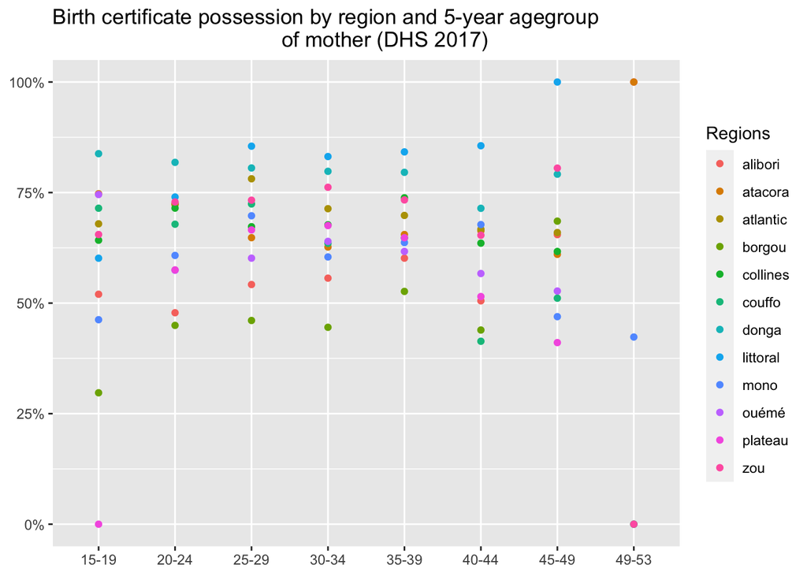

```r
#plot birth certificate possession by region for 5-year age groups
Plot_U5BC(data = bjbrirpr71fl, var1 = ~birth_cert , var2 = ~hv024+agegroup_5,
            caption = "Birth certificate possession by region and 5-year agegroup
                                       of mother (DHS 2017)")
```

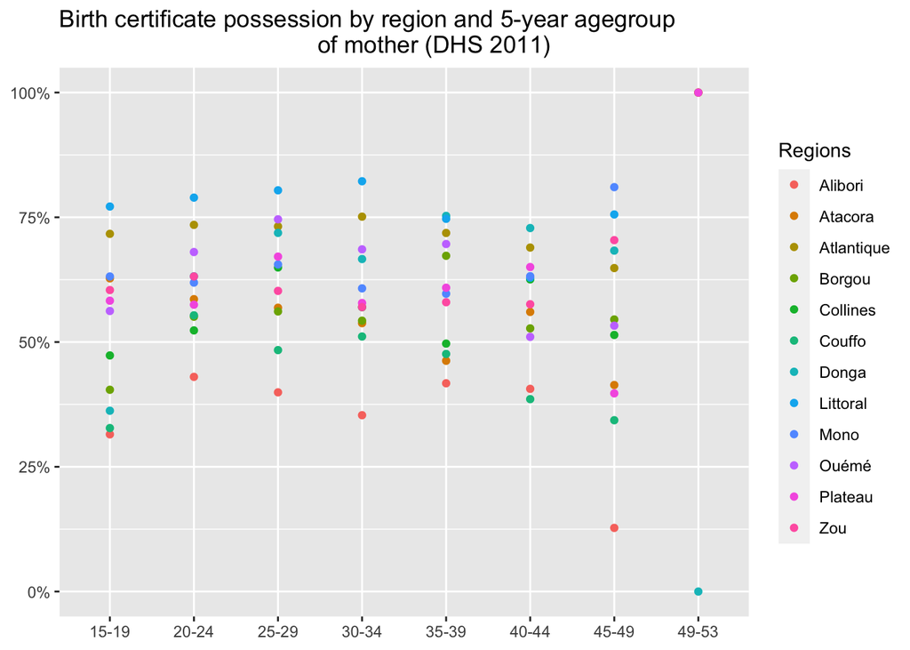

```r
Plot_U5BC(data = bjbrirpr61fl, var1 = ~birth_cert , var2 = ~hv024+agegroup_5,
            caption = "Birth certificate possession by region and 5-year agegroup
                                       of mother (DHS 2011)")
```

### 3.2.2 Plot Birth Registration Completeness by region

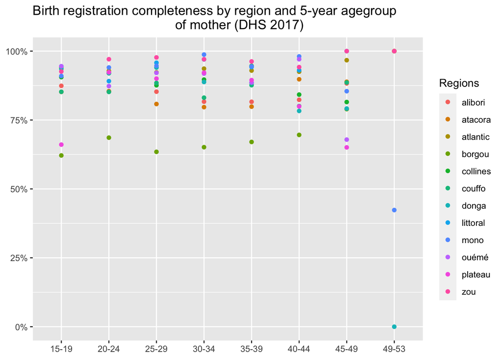

```r
#plot birth registration by region and age group

Plot_CU5WBR(data = bjbrirpr71fl, var1 = ~birth_reg , var2 = ~hv024+agegroup_5,
            caption = "Birth registration completeness by region and 5-year agegroup
                                       of mother (DHS 2017)")
```

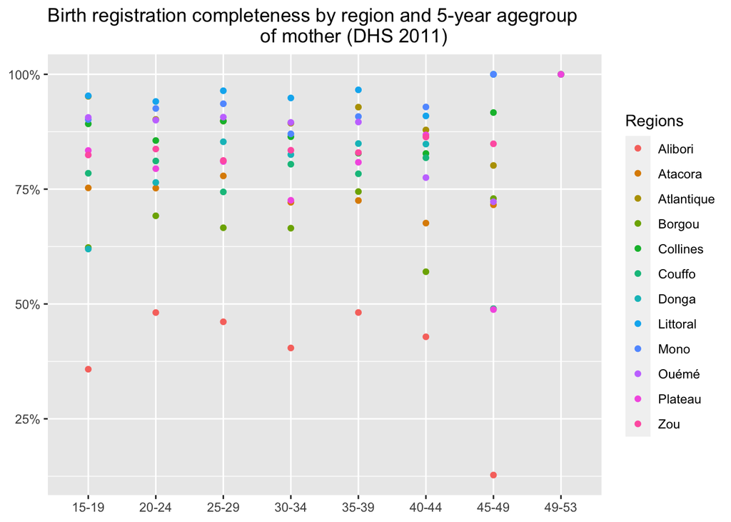

```r
Plot_CU5WBR(data = bjbrirpr61fl, var1 = ~birth_reg , var2 = ~hv024+agegroup_5,
            caption = "Birth registration completeness by region and 5-year agegroup
                                        of mother (DHS 2011)")
```

# 4. Adolescent Birth Rate and Birth Registration Completeness / Birth certificate possession by Region

## 4.1. Functions for Adolescent Birth Rate and Birth Registration Completeness / Birth certificate possession by Region

```r
ABRC <- function(WomenData, DataPrepared, indicator, caption) {

# tabulate indicator "children under age 5 who have certificate or are registered"
# by 5-year agegroup of mother and region

birth_cert_or_reg <-
U5BCOR_df(data = DataPrepared, var1 = indicator, var2 =  ~hv024+agegroup_5) %>%
rename(hv024 = Region)


#calculating the age specific fertility rate
asfr <- fert(women, Indicator = "asfr", Cluster = "v021", Class = "v024")

#creating a matching variable for the fertility rate table
asfr$matching <- paste(asfr$Class, asfr$AGE, sep = "-")

#creating a matching variable for the birth certificate or registration by region table
birth_cert_or_reg$matching <-
paste(birth_cert_or_reg$hv024,
      birth_cert_or_reg$agegroup_5, sep = "-")

#joining asfr table to birth_cert_or_reg table
asfr_cert_or_reg <- asfr %>%
inner_join(birth_cert_or_reg, by = "matching")

asfr_cert_or_reg <-
rename(asfr_cert_or_reg, Region = Class)

asfr_cert_or_reg <-
select(asfr_cert_or_reg, -LCI, -UCI, -RSE, -matching, -agegroup_5, -hv024)
asfr_cert_or_reg <-
kable(asfr_cert_or_reg, format = "pipe", caption = caption)
return(asfr_cert_or_reg)
}




ABRC_df <- function(WomenData, DataPrepared, indicator) {

# tabulate indicator "children under age 5 who have certificate or are registered"
# by 5-year agegroup of mother and region

birth_cert_or_reg <-
U5BCOR_df(data = DataPrepared, var1 = indicator, var2 =  ~hv024+agegroup_5) %>%
rename(hv024 = Region)


#calculating the age specific fertility rate
asfr <- fert(women, Indicator = "asfr", Cluster = "v021", Class = "v024")

#creating a matching variable for the fertility rate table
asfr$matching <- paste(asfr$Class, asfr$AGE, sep = "-")

#creating a matching variable for the birth certificate or registration by region table
birth_cert_or_reg$matching <-
paste(birth_cert_or_reg$hv024,
      birth_cert_or_reg$agegroup_5, sep = "-")

#joining asfr table to birth_cert_or_reg table
asfr_cert <- asfr %>%
inner_join(birth_cert_or_reg, by = "matching")
return(asfr_cert)
}

plot_ABRCert <- function(WomenData, DataPrepared, indicator = ~birth_cert) {

bj_asfr_cert <- ABRC_df (WomenData, DataPrepared, indicator)
bj_asfr_cert %>%
filter(agegroup_5 == "15-19") %>%
ggplot(aes(x = birth_cert, y = ASFR)) +
geom_point() +
labs(title =  NULL,
     x = "Birth Certificate Possession", y = "Adolescent Birth Rate",
     color = "Regions") +
scale_x_continuous(labels = scales::percent,
                   expand = c(0.5, 0), limits = c(0,NA)) +
geom_text_repel(size = 3, aes(label = hv024),
          hjust = -0.1, vjust = -0.3, position = position_dodge(width=2),
          color = "black")
}

plot_ABRReg <- function(WomenData, DataPrepared, indicator = ~birth_reg) {

bj_asfr_reg <- ABRC_df (WomenData, DataPrepared, indicator)
bj_asfr_reg %>%
filter(agegroup_5 == "15-19") %>%
ggplot(aes(x = birth_reg, y = ASFR)) +
geom_point() +
labs(title =  NULL,
     x = "Birth Registration Completeness", y = "Adolescent Birth Rate",
     color = "Regions") +
scale_x_continuous(labels = scales::percent,
                   expand = c(0.5, 0), limits = c(0,NA)) +
geom_text_repel(size = 3, aes(label = hv024),
          hjust = -0.1, vjust = -0.3, position = position_dodge(width=2),
          color = "black")
}
```

## 4.2 Tabulate Age Specific Fertility Rate and Birth Certificate Possession by Region

```r
#reloading women dataset

women <-
read_dta("/Users/ramoudaneorousannou/Downloads/Dhs_data/BJIR71DT/BJIR71FL.DTA")

(bj_abrcert <- ABRC(WomenData = women, DataPrepared = bjbrirpr71fl, indicator = ~birth_cert, caption = "Adolescent Birth Rate and Birth Certificate Possession"))
```

```
##
##  The current function calculated ASFR based on a reference period of 36 months
##  The reference period ended at the time of the interview, in 2018.08 OR Nov - NA 2017
##  The average reference period is 2016.58
```

Adolescent Birth Rate and Birth Certificate Possession

| Region | AGE | ASFR | SE | N | WN | DEFT | birth_cert | se | ci_l | ci_u |
| --- | --- | --- | --- | --- | --- | --- | --- | --- | --- | --- |
| alibori | 15-19 | 162.520 | 10.862 | 1117 | 1244 | 1.100 | 0.5200105 | 0.0626841 | 0.3971519 | 0.6428691 |
| alibori | 20-24 | 287.625 | 11.690 | 983 | 1114 | 0.972 | 0.4782201 | 0.0461671 | 0.3877344 | 0.5687059 |
| alibori | 25-29 | 280.378 | 14.187 | 903 | 1027 | 1.142 | 0.5419853 | 0.0507105 | 0.4425945 | 0.6413761 |
| alibori | 30-34 | 229.856 | 17.688 | 655 | 685 | 1.136 | 0.5564263 | 0.0609708 | 0.4369258 | 0.6759269 |
| alibori | 35-39 | 162.007 | 15.217 | 481 | 528 | 1.043 | 0.6016266 | 0.0566947 | 0.4905071 | 0.7127462 |
| alibori | 40-44 | 80.536 | 13.889 | 400 | 439 | 1.068 | 0.5051294 | 0.0520508 | 0.4031118 | 0.6071471 |
| alibori | 45-49 | 29.476 | 12.116 | 237 | 262 | 1.118 | 0.6548358 | 0.1280175 | 0.4039262 | 0.9057455 |
| atacora | 15-19 | 135.754 | 13.258 | 912 | 870 | 1.285 | 0.7473417 | 0.0757118 | 0.5989492 | 0.8957341 |
| atacora | 20-24 | 280.845 | 17.493 | 764 | 721 | 1.348 | 0.7225800 | 0.0337808 | 0.6563708 | 0.7887893 |
| atacora | 25-29 | 292.035 | 14.456 | 635 | 579 | 0.944 | 0.6479657 | 0.0378330 | 0.5738145 | 0.7221169 |
| atacora | 30-34 | 252.094 | 14.962 | 483 | 442 | 0.847 | 0.6267992 | 0.0357875 | 0.5566570 | 0.6969413 |
| atacora | 35-39 | 192.004 | 23.012 | 441 | 409 | 1.273 | 0.6550777 | 0.0512104 | 0.5547071 | 0.7554483 |
| atacora | 40-44 | 140.318 | 20.811 | 359 | 329 | 1.113 | 0.6636628 | 0.0442022 | 0.5770281 | 0.7502975 |
| atacora | 45-49 | 49.157 | 14.120 | 267 | 253 | 1.012 | 0.6103091 | 0.0790312 | 0.4554109 | 0.7652074 |
| atlantic | 15-19 | 82.703 | 12.570 | 1020 | 1178 | 1.445 | 0.6792995 | 0.1509065 | 0.3835282 | 0.9750708 |
| atlantic | 20-24 | 219.698 | 18.185 | 880 | 1059 | 1.500 | 0.7250435 | 0.0345936 | 0.6572413 | 0.7928457 |
| atlantic | 25-29 | 267.903 | 16.556 | 897 | 1079 | 1.185 | 0.7811957 | 0.0262694 | 0.7297087 | 0.8326828 |
| atlantic | 30-34 | 211.922 | 16.853 | 662 | 823 | 1.100 | 0.7135502 | 0.0340101 | 0.6468917 | 0.7802088 |
| atlantic | 35-39 | 137.319 | 16.999 | 550 | 641 | 1.272 | 0.6982765 | 0.0390777 | 0.6216857 | 0.7748673 |
| atlantic | 40-44 | 46.009 | 11.379 | 463 | 584 | 0.963 | 0.6669442 | 0.0851750 | 0.5000043 | 0.8338842 |
| atlantic | 45-49 | 18.334 | 8.521 | 294 | 346 | 1.079 | 0.6596191 | 0.1203814 | 0.4236759 | 0.8955623 |
| borgou | 15-19 | 137.167 | 11.592 | 1106 | 1183 | 1.141 | 0.2971743 | 0.0615092 | 0.1766186 | 0.4177301 |
| borgou | 20-24 | 272.740 | 15.300 | 1135 | 1189 | 1.371 | 0.4496147 | 0.0474715 | 0.3565722 | 0.5426572 |
| borgou | 25-29 | 281.855 | 15.960 | 1008 | 1023 | 1.375 | 0.4607005 | 0.0435069 | 0.3754287 | 0.5459724 |
| borgou | 30-34 | 250.823 | 15.541 | 711 | 728 | 1.084 | 0.4452796 | 0.0460476 | 0.3550279 | 0.5355313 |
| borgou | 35-39 | 169.801 | 24.117 | 470 | 482 | 1.418 | 0.5264565 | 0.0557632 | 0.4171627 | 0.6357503 |
| borgou | 40-44 | 105.801 | 15.171 | 334 | 352 | 0.952 | 0.4390942 | 0.0667464 | 0.3082737 | 0.5699148 |
| borgou | 45-49 | 28.280 | 13.502 | 182 | 187 | 0.959 | 0.6854001 | 0.1188249 | 0.4525076 | 0.9182926 |
| collines | 15-19 | 101.620 | 10.497 | 943 | 780 | 1.091 | 0.6421977 | 0.0553916 | 0.5336321 | 0.7507633 |
| collines | 20-24 | 242.149 | 17.825 | 744 | 640 | 1.249 | 0.7147823 | 0.0403795 | 0.6356399 | 0.7939247 |

[output cut: 54 more lines]

## 4.3 Plot Adolescent Birth Rate and Birth Certificate Possession by Region

```
##
##  The current function calculated ASFR based on a reference period of 36 months
##  The reference period ended at the time of the interview, in 2018.08 OR Nov - NA 2017
##  The average reference period is 2016.58
```

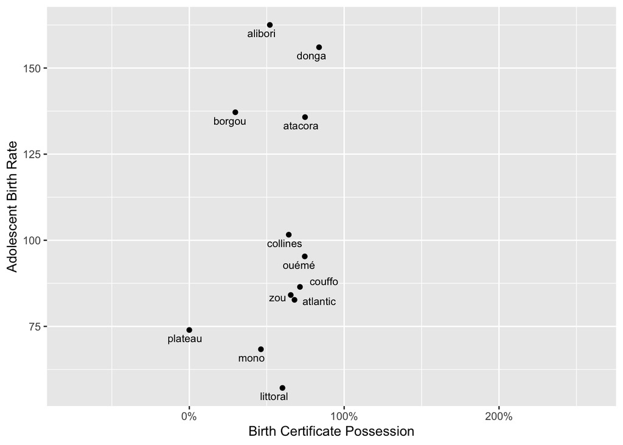

```r
plot_ABRCert(WomenData = women, DataPrepared = bjbrirpr71fl)
```

## 4.4 Tabulate Adolescent Birth Rate and Birth Registration Completeness by Region (5-year age groups)

```r
(bj_abrreg <- ABRC(WomenData = women, DataPrepared = bjbrirpr71fl, indicator = ~birth_reg,
                   caption = "Adolescent Birth Rate and Birth
                   Registration Completeness"))
```

```
##
##  The current function calculated ASFR based on a reference period of 36 months
##  The reference period ended at the time of the interview, in 2018.08 OR Nov - NA 2017
##  The average reference period is 2016.58
```

Adolescent Birth Rate and Birth Registration Completeness

| Region | AGE | ASFR | SE | N | WN | DEFT | birth_reg | se | ci_l | ci_u |
| --- | --- | --- | --- | --- | --- | --- | --- | --- | --- | --- |
| alibori | 15-19 | 162.520 | 10.862 | 1117 | 1244 | 1.100 | 0.8740776 | 0.0355178 | 0.8044639 | 0.9436912 |
| alibori | 20-24 | 287.625 | 11.690 | 983 | 1114 | 0.972 | 0.8528553 | 0.0290554 | 0.7959077 | 0.9098028 |
| alibori | 25-29 | 280.378 | 14.187 | 903 | 1027 | 1.142 | 0.8528118 | 0.0335239 | 0.7871061 | 0.9185174 |
| alibori | 30-34 | 229.856 | 17.688 | 655 | 685 | 1.136 | 0.8166715 | 0.0313489 | 0.7552287 | 0.8781143 |
| alibori | 35-39 | 162.007 | 15.217 | 481 | 528 | 1.043 | 0.8161374 | 0.0438925 | 0.7301096 | 0.9021652 |
| alibori | 40-44 | 80.536 | 13.889 | 400 | 439 | 1.068 | 0.8234152 | 0.0492314 | 0.7269234 | 0.9199070 |
| alibori | 45-49 | 29.476 | 12.116 | 237 | 262 | 1.118 | 0.8828013 | 0.0654936 | 0.7544362 | 1.0111663 |
| atacora | 15-19 | 135.754 | 13.258 | 912 | 870 | 1.285 | 0.8521456 | 0.0481192 | 0.7578337 | 0.9464576 |
| atacora | 20-24 | 280.845 | 17.493 | 764 | 721 | 1.348 | 0.8546733 | 0.0309435 | 0.7940252 | 0.9153215 |
| atacora | 25-29 | 292.035 | 14.456 | 635 | 579 | 0.944 | 0.8080592 | 0.0394233 | 0.7307910 | 0.8853273 |
| atacora | 30-34 | 252.094 | 14.962 | 483 | 442 | 0.847 | 0.7967274 | 0.0334117 | 0.7312416 | 0.8622132 |
| atacora | 35-39 | 192.004 | 23.012 | 441 | 409 | 1.273 | 0.7984412 | 0.0360100 | 0.7278628 | 0.8690196 |
| atacora | 40-44 | 140.318 | 20.811 | 359 | 329 | 1.113 | 0.8978454 | 0.0370097 | 0.8253077 | 0.9703830 |
| atacora | 45-49 | 49.157 | 14.120 | 267 | 253 | 1.012 | 0.8888086 | 0.0618539 | 0.7675772 | 1.0100400 |
| atlantic | 15-19 | 82.703 | 12.570 | 1020 | 1178 | 1.445 | 0.9392593 | 0.0519054 | 0.8375265 | 1.0409921 |
| atlantic | 20-24 | 219.698 | 18.185 | 880 | 1059 | 1.500 | 0.9283366 | 0.0201768 | 0.8887907 | 0.9678825 |
| atlantic | 25-29 | 267.903 | 16.556 | 897 | 1079 | 1.185 | 0.9228147 | 0.0221862 | 0.8793306 | 0.9662988 |
| atlantic | 30-34 | 211.922 | 16.853 | 662 | 823 | 1.100 | 0.9363599 | 0.0148738 | 0.9072078 | 0.9655120 |
| atlantic | 35-39 | 137.319 | 16.999 | 550 | 641 | 1.272 | 0.9294364 | 0.0194199 | 0.8913741 | 0.9674987 |
| atlantic | 40-44 | 46.009 | 11.379 | 463 | 584 | 0.963 | 0.9252979 | 0.0430304 | 0.8409599 | 1.0096360 |
| atlantic | 45-49 | 18.334 | 8.521 | 294 | 346 | 1.079 | 0.9670423 | 0.0332851 | 0.9018046 | 1.0322800 |
| borgou | 15-19 | 137.167 | 11.592 | 1106 | 1183 | 1.141 | 0.6214329 | 0.0661504 | 0.4917806 | 0.7510853 |
| borgou | 20-24 | 272.740 | 15.300 | 1135 | 1189 | 1.371 | 0.6859622 | 0.0418489 | 0.6039398 | 0.7679845 |
| borgou | 25-29 | 281.855 | 15.960 | 1008 | 1023 | 1.375 | 0.6345912 | 0.0447156 | 0.5469502 | 0.7222322 |
| borgou | 30-34 | 250.823 | 15.541 | 711 | 728 | 1.084 | 0.6514154 | 0.0525082 | 0.5485012 | 0.7543297 |
| borgou | 35-39 | 169.801 | 24.117 | 470 | 482 | 1.418 | 0.6704205 | 0.0518691 | 0.5687590 | 0.7720821 |
| borgou | 40-44 | 105.801 | 15.171 | 334 | 352 | 0.952 | 0.6960128 | 0.0542010 | 0.5897807 | 0.8022449 |
| borgou | 45-49 | 28.280 | 13.502 | 182 | 187 | 0.959 | 0.7895610 | 0.0988318 | 0.5958543 | 0.9832678 |
| collines | 15-19 | 101.620 | 10.497 | 943 | 780 | 1.091 | 0.9055984 | 0.0511766 | 0.8052940 | 1.0059027 |
| collines | 20-24 | 242.149 | 17.825 | 744 | 640 | 1.249 | 0.9197785 | 0.0211889 | 0.8782490 | 0.9613081 |

[output cut: 54 more lines]

## 4.5 Plot Adolescent Birth Rate and Birth Registration Completeness by Region (5-year age groups)

```
##
##  The current function calculated ASFR based on a reference period of 36 months
##  The reference period ended at the time of the interview, in 2018.08 OR Nov - NA 2017
##  The average reference period is 2016.58
```

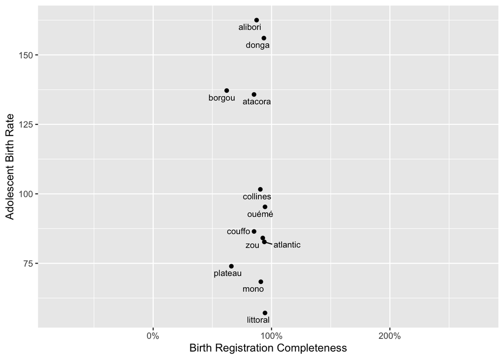

```r
plot_ABRReg(WomenData = women, DataPrepared = bjbrirpr71fl)
```

## 4.6 Modifcation of the ASFR function from DHS.rates package to calculate ASFR for 10-year age groups

```r
# Modifying the DataPrepare function

DataPrepare <- function(Dat, PeriodEnd = NULL, Period = NULL)
{
  Dat$rweight = Dat$v005 / 1000000

  if (!is.null(PeriodEnd)) {
    dates <- paste(PeriodEnd, "01", sep = "-")
    PeriodEndm <- as.numeric(format(as.Date(dates), "%m"))
    PeriodEndy <- as.numeric(format(as.Date(dates), "%Y"))
    PeriodEndcmc <- ((PeriodEndy - 1900) * 12) + PeriodEndm
  }

  # 1. Construct a children data ##########################################################
  myvars <- c(paste("ID"), paste("v021"), paste("v005"), paste("v008"), paste("v011"),
              paste("v022"), paste("allwoment"), paste("rweight"),
              paste("b3_0", 1:9, sep = ""), paste("b3_", 10:20, sep = ""))

  def <- reshape::melt(as.data.frame(Dat[myvars]), id = c("ID", "v021", "v005", "v008", "v011",
                                                          "v022", "rweight", "allwoment"))

  names(def)[names(def) == c("value")] <- c("B3")
  def$variable <- NULL

  # 2. Briths to women 15-49 during the reference period  #################################
  if (is.null(PeriodEnd)){def$periodend = def$v008} else {def$periodend = PeriodEndcmc}

  if (is.null(Period)){def$period = 36} else {def$period = Period}
  def$age10 = as.integer((def$B3 - def$v011) / 120)
  #modified age5 in the intial code into age10 to calculate ten years age groups

  def$birth <- 0
  def$birth[def$periodend - def$B3 > 0 &
              def$periodend - def$B3 <= def$period & def$age10 >= 0] <- 1
  def$B3 <- NULL
  def$exposure = 0
  def$exposureg = 0
  def <- def[stats::complete.cases(def$age10), ]

  # 3. Exposure of women 15-49  ###########################################################
  newdata <- c("ID", "v021", "v005", "v008", "v011", "v022", "rweight", "allwoment")
  def2 <- Dat[newdata]

  if (is.null(PeriodEnd)){def2$periodend = def2$v008} else {def2$periodend = PeriodEndcmc}

  if (is.null(Period)){def2$period = 36} else {def2$period = Period}
  def2$agem   = def2$periodend - def2$v011 - 1 #age at the end of the period
  def2$age10   = as.integer(def2$agem / 120) #age group at the end of the period
  # modified to consider ten years age groups

  def2$higexp = def2$agem - (def2$age10 * 120) + 1  #Exposure (number of months) in current age group
  def2$higexp <- ifelse(def2$higexp >= def2$period, def2$period, def2$higexp)
  def2$age10   = def2$age10
  def2 <- def2[def2$age10 >= 0, ]

  ## Exposure in previous age group #####
  def2$lowexp <- ifelse(def2$higexp < def2$period & def2$age10 >= 1 , def2$period - def2$higexp, 0)
  def2$birth = 0
  def2$agem <- NULL
  def2l <- def2
  def2$lowexp <- NULL
  def2l$higexp <- NULL
  names(def2)[names(def2) == c("higexp")] <- c("exposure")
  names(def2l)[names(def2l) == c("lowexp")] <- c("exposure")
  def2l$age10 = def2l$age10 -1
  def3 <- rbind(def2, def2l)
  def3$exposure = def3$exposure / 12
  def3$exposureg <- ifelse(def3$age10 == 3, 0, def3$exposure)

  def4 <- rbind(def, def3)
  def4$birth = def4$birth * 1000

  BirthEx <- merge(stats::aggregate(list(def4$birth, def4$exposure, def4$exposureg),
                                    list(def4$ID, def4$v021, def4$v022, def4$age10, def4$allwoment), sum),
                   stats::aggregate(def4$rweight, list(def4$ID), mean), by = "Group.1")

  names(BirthEx) <- c("ID", "v021", "v022", "age10", "allwoment", "birth", "exposure",
                      "exposureg", "rweight")
  BirthEx <- BirthEx[BirthEx$birth != 0 | BirthEx$exposure != 0, ]
  BirthEx$id <- c(as.factor(BirthEx$v021))

  return(BirthEx)
}



# Modifying the ASFR function

ASFR <- function(Data.Name, CL = NULL, EverMW = NULL, AWFact = NULL,
                 PeriodEnd = NULL, Period = NULL, Class = NULL) {

  Data.Name <- Data.Name[!Data.Name$v005 == 0, ]
  Data.Name$ID <- seq.int(nrow(Data.Name))

  # The CI confidence level
  if (is.null(CL)) {
    Z <- stats::qnorm(.025,lower.tail=FALSE)
  } else {
    Z <- stats::qnorm((100-CL)/200,lower.tail=FALSE)
  }

  ## Title for the results #########################
  if (is.null(Period)){Periodmsg = 36} else {Periodmsg = Period}

  if (is.null(PeriodEnd)){
    PeriodEndy_ <- as.integer((mean(Data.Name$v008) - 1)/12)+1900
    PeriodEndm_ <- round(mean(Data.Name$v008) - ((PeriodEndy_ - 1900) * 12),0)

    PeriodEndm_m <- round(min(Data.Name$v008) - ((PeriodEndy_ - 1900) * 12),0)
    PeriodEndm_x <- round(max(Data.Name$v008) - ((PeriodEndy_ - 1900) * 12),0)
  }
  else {
    dates <- paste(PeriodEnd, "01", sep = "-")
    PeriodEndm_ <- as.numeric(format(as.Date(dates), "%m"))
    PeriodEndy_ <- as.numeric(format(as.Date(dates), "%Y"))

    if (PeriodEndm_ >=  round(mean(Data.Name$v008) - (((as.integer((mean(Data.Name$v008) - 1)/12)+1900) - 1900) * 12),0) &
        PeriodEndy_ >= as.integer((mean(Data.Name$v008) - 1)/12)+1900)

      message(crayon::bold("Note:", "\n",
                           "You specified a reference period that ends after the survey fieldwork dates....."), "\n",
              "1. Make sure the dates in the survey are coded according to the Gregorian calendar.", "\n",
              "2. If the dates are coded according to the Gregorian calendar, use a proper PeriodEnd that came before the time of the survey.", "\n",
              "3. If the dates are not coded according to the Gregorian calendar, use a PeriodEnd according to the used calendar.")

  }


  if (is.null(PeriodEnd)){
    cat("\n", crayon::white$bgBlue$bold("The current function calculated ASFR based on a reference period of"),
        crayon::red$bold$underline(Periodmsg), crayon::white$bold$bgBlue("months"), "\n", crayon::white$bold$bgBlue("The reference period ended at the time of the interview, in"), crayon::red$bold$underline(PeriodEndy_ + round(PeriodEndm_/12,digits=2)), "OR", crayon::red$bold$underline(month.abb[PeriodEndm_m]), "-", crayon::red$bold$underline(month.abb[PeriodEndm_x]), crayon::red$bold$underline(PeriodEndy_), "\n",
        crayon::white$bold$bgBlue("The average reference period is"), crayon::red$bold$underline(round((PeriodEndy_ + PeriodEndm_/12)-(Periodmsg/24), digits =2)), "\n")

  }
  else {
    cat("\n", crayon::white$bgBlue$bold("The current function calculated ASFR based on a reference period of"),
        crayon::red$bold$underline(Periodmsg), crayon::white$bold$bgBlue("months"), "\n", crayon::white$bold$bgBlue("The reference period ended in"), crayon::red$bold$underline(PeriodEndy_ + round(PeriodEndm_/12,digits=2)), "OR", crayon::red$bold$underline(month.abb[PeriodEndm_]), crayon::red$bold$underline(PeriodEndy_), "\n" ,
        crayon::white$bold$bgBlue("The average reference period is"), crayon::red$bold$underline(round((PeriodEndy_ + PeriodEndm_/12)-(Periodmsg/24), digits =2)), "\n")

  }

  ####### For Overall Indicators; no Class #############################################
  if (is.null(Class)) {
    if (is.null(EverMW)) {
      Data.Name$allwoment <- 1
    } else {
      Data.Name$allwoment <- Data.Name$awfactt / 100
    }
    BirthEx <- DataPrepare(Data.Name, PeriodEnd, Period)
    BirthEx$exposure <- BirthEx$allwoment * BirthEx$exposure

    dstrat <- survey::svydesign(id = ~ v021, strata = ~ v022, weights = ~ rweight, data = BirthEx)

    AGE <- AGE <- c("15-24", "25-34", "35-44", "45-54")
    # defined 10 years age groups instead of 5

    ASFR <- (survey::svyby(~ birth, by = ~ age10, denominator = ~ exposure,
                           design = dstrat, survey::svyratio))[, 2]

    SE <- (survey::svyby(~ birth, by = ~ age10, denominator = ~ exposure,
                         design = dstrat, survey::svyratio))[, 3]

    N <- stats::aggregate(BirthEx$exposure, list(BirthEx$age10), sum)$x

    WN <- (survey::svyby(~ exposure, by = ~ age10, design = dstrat, survey::svytotal))$exposure

    DEFT <- sqrt(survey::svyby(~ birth, by = ~ age10, denominator = ~ exposure,
                               design = dstrat, deff = "replace", survey::svyratio)$DEff)

    RSE <- survey::cv(survey::svyby(~ birth, by = ~ age10, denominator = ~ exposure,
                                    design = dstrat, survey::svyratio))
    LCI = ASFR - (Z * SE)
    LCI[LCI <= 0] = 0
    UCI <- ASFR + (Z * SE)

    RESULTS <- cbind.data.frame(AGE, round(ASFR, 3), round(SE, 3), round(N, 0), round(WN, 0),
                                round(DEFT, 3), round(RSE, 3), round(LCI, 3), round(UCI, 3))

    names(RESULTS) <- c("AGE", "ASFR", "SE", "N", "WN", "DEFT", "RSE", "LCI", "UCI")
    list(RESULTS)

  } else {

    ####### For Class Indicators; #############################################

    Data.Name[[Class]] <- haven::as_factor(Data.Name[[Class]])
    #Data.Name$DomID <- c(as.factor(Data.Name[[Class]]))
    Data.Name$DomID  <- c(as.numeric(Data.Name[[Class]]))

    if (is.null(EverMW)) {
      Data.Name$allwoment <- 1
    } else if (is.null(AWFact)) {
      Data.Name$allwoment <- Data.Name$awfactt / 100
    } else {
      Data.Name$allwoment <- Data.Name[[AWFact]] / 100
    }
    BirthEx <- DataPrepare(Data.Name, PeriodEnd, Period)
    BirthEx$exposure <- BirthEx$allwoment * BirthEx$exposure

    Data.class <- Data.Name[, c("ID", "DomID", Class)]
    Dat <- merge(BirthEx, Data.class, by = "ID", all.x = TRUE)

    RESULTS <- matrix(0, 1, ncol = 10)
    dimnames(RESULTS) <- list(NULL, c("Class", "AGE", "ASFR", "SE", "N", "WN",
                                      "DEFT", "RSE", "LCI", "UCI"))
    RESULTS <- as.data.frame(RESULTS)

    for (j in 1:(max(as.numeric(Dat$DomID)))) {
      DatD <- Dat[Dat$DomID == j, ]

      dstrat <- survey::svydesign(id = ~ v021, strata = ~ v022, weights = ~ rweight, data = DatD)

      AGE <- c("15-24", "25-34", "35-44", "45-54")
      # defined 10 years age groups instead of 5

      ASFR <- (survey::svyby(~ birth, by = ~ age10, denominator = ~ exposure,
                             design = dstrat, survey::svyratio))[, 2]

      SE <- (survey::svyby(~ birth, by = ~ age10, denominator = ~ exposure,
                           design = dstrat, survey::svyratio))[, 3]

      N <- stats::aggregate(DatD$exposure, list(DatD$age10), sum)$x

      WN <- (survey::svyby(~ exposure, by = ~ age10, design = dstrat, survey::svytotal))$exposure

      DEFT <- sqrt(survey::svyby(~ birth, by = ~ age10, denominator = ~ exposure,
                                 design = dstrat, deff = "replace", survey::svyratio)$DEff)

      RSE <- survey::cv(survey::svyby(~ birth, by = ~ age10, denominator = ~ exposure,
                                      design = dstrat, survey::svyratio))

      LCI = ASFR - (Z * SE)
      LCI[LCI <= 0] = 0
      UCI <- ASFR + (Z * SE)

      RESULTS0 <- cbind.data.frame(attributes(Dat[[Class]])$levels[[j]], AGE, round(ASFR, 3),
                                   round(SE, 3), round(N, 0), round(WN, 0), round(DEFT, 3),
                                   round(RSE, 3), round(LCI, 3), round(UCI, 3))

      names(RESULTS0) <- c("Class", "AGE", "ASFR", "SE", "N", "WN", "DEFT", "RSE", "LCI", "UCI")
      RESULTS <- rbind(RESULTS, RESULTS0)
    }

    list(RESULTS)
  }
}
```

```r
# calculate age specific fertility rate for 10 years agegroups
# by applying the modified ASFR function

bjir_asfr_10 <-
read_dta("/Users/ramoudaneorousannou/Downloads/Dhs_data/BJIR71DT/BJIR71FL.DTA")

bj_asfr_10 <- as.data.frame(ASFR(bjir_asfr_10,  Class = "v024"))
```

```
##
##  The current function calculated ASFR based on a reference period of 36 months
##  The reference period ended at the time of the interview, in 2018.08 OR Nov - NA 2017
##  The average reference period is 2016.58
```

```r
bj_asfr_10
```

|  | Class | AGE | ASFR | SE | N | WN | DEFT | RSE | LCI | UCI |
| --- | --- | --- | --- | --- | --- | --- | --- | --- | --- | --- |
| 1 | 0 | 0 | 0.000 | 0.000 | 0 | 0 | 0.000 | 0.000 | 0.000 | 0.000 |
| 11 | alibori | 15-24 | 127.978 | 10.457 | 1433 | 1580 | 1.253 | 0.082 | 107.482 | 148.474 |
| 2 | alibori | 25-34 | 284.149 | 9.255 | 1886 | 2140 | 1.140 | 0.033 | 266.009 | 302.290 |
| 3 | alibori | 35-44 | 200.306 | 10.662 | 1135 | 1213 | 0.987 | 0.053 | 179.409 | 221.203 |
| 4 | alibori | 45-54 | 61.460 | 9.050 | 637 | 701 | 0.963 | 0.147 | 43.722 | 79.199 |
| 12 | atacora | 15-24 | 103.189 | 11.304 | 1227 | 1174 | 1.353 | 0.110 | 81.033 | 125.344 |
| 21 | atacora | 25-34 | 285.827 | 10.551 | 1399 | 1299 | 1.124 | 0.037 | 265.148 | 306.506 |
| 31 | atacora | 35-44 | 223.199 | 15.138 | 924 | 851 | 1.248 | 0.068 | 193.529 | 252.870 |
| 41 | atacora | 45-54 | 100.659 | 13.558 | 626 | 582 | 1.067 | 0.135 | 74.086 | 127.233 |
| 13 | atlantic | 15-24 | 62.763 | 9.716 | 1360 | 1578 | 1.436 | 0.155 | 43.720 | 81.806 |

[output cut: 39 more lines]

```r
#creating a matching variable for the fertility rate table
bj_asfr_10$matching <- paste(bj_asfr_10$Class, bj_asfr_10$AGE, sep = "-")


birth_reg_by_region_agegroup_10 <-
U5BCOR_df(data = bjbrirpr71fl, var1 = ~birth_reg, var2 =  ~hv024+agegroup_10) %>%
rename(hv024 = Region)

#creating a matching variable for the birth registration completeness by region table (10 years agegroup)

birth_reg_by_region_agegroup_10$matching <-
paste(birth_reg_by_region_agegroup_10$hv024,
      birth_reg_by_region_agegroup_10$agegroup_10, sep = "-")

bj_asfr_reg_10 <- bj_asfr_10 %>%
inner_join(birth_reg_by_region_agegroup_10, by = "matching")

bj_asfr_reg_10 %>%
rename(c("Region" = "Class",
         "Birth Reg" = "birth_reg",
         "Std E" = "se",
         "CI_L" = "ci_l",
         "CI_U" = "ci_u")) %>%
select(-LCI, -UCI, -RSE, -matching, -WN, -agegroup_10, -hv024) %>%
kable(format = "pipe", caption = "Age Specific Fertility Rate and
      Birth Certificate Possession (10-year agegroup)")
```

| Region | AGE | ASFR | SE | N | DEFT | Birth Reg | Std E | CI_L | CI_U |
| --- | --- | --- | --- | --- | --- | --- | --- | --- | --- |
| alibori | 15-24 | 127.978 | 10.457 | 1433 | 1.253 | 0.8565081 | 0.0269720 | 0.8036440 | 0.9093723 |
| alibori | 25-34 | 284.149 | 9.255 | 1886 | 1.140 | 0.8376791 | 0.0277554 | 0.7832795 | 0.8920788 |
| alibori | 35-44 | 200.306 | 10.662 | 1135 | 0.987 | 0.8190302 | 0.0439104 | 0.7329674 | 0.9050929 |
| atacora | 15-24 | 103.189 | 11.304 | 1227 | 1.353 | 0.8542856 | 0.0288396 | 0.7977610 | 0.9108101 |
| atacora | 25-34 | 285.827 | 10.551 | 1399 | 1.124 | 0.8034678 | 0.0299595 | 0.7447484 | 0.8621873 |
| atacora | 35-44 | 223.199 | 15.138 | 924 | 1.248 | 0.8343715 | 0.0298738 | 0.7758200 | 0.8929230 |
| atlantic | 15-24 | 62.763 | 9.716 | 1360 | 1.436 | 0.9293174 | 0.0211627 | 0.8878392 | 0.9707956 |
| atlantic | 25-34 | 244.029 | 13.342 | 1777 | 1.477 | 0.9288732 | 0.0150959 | 0.8992858 | 0.9584606 |
| atlantic | 35-44 | 179.249 | 11.865 | 1212 | 1.156 | 0.9283095 | 0.0176637 | 0.8936894 | 0.9629297 |
| borgou | 15-24 | 105.915 | 9.466 | 1456 | 1.154 | 0.6759853 | 0.0406892 | 0.5962360 | 0.7557346 |
| borgou | 25-34 | 276.957 | 12.171 | 2143 | 1.577 | 0.6418873 | 0.0450592 | 0.5535729 | 0.7302017 |
| borgou | 35-44 | 218.571 | 11.832 | 1181 | 1.095 | 0.6785742 | 0.0450122 | 0.5903519 | 0.7667965 |
| collines | 15-24 | 70.965 | 8.334 | 1361 | 1.194 | 0.9177850 | 0.0211831 | 0.8762668 | 0.9593032 |
| collines | 25-34 | 263.638 | 13.012 | 1308 | 1.210 | 0.8847950 | 0.0247387 | 0.8363081 | 0.9332819 |
| collines | 35-44 | 170.093 | 10.250 | 950 | 0.927 | 0.9134427 | 0.0344804 | 0.8458623 | 0.9810231 |
| couffo | 15-24 | 65.138 | 10.187 | 835 | 1.142 | 0.8520334 | 0.0330168 | 0.7873217 | 0.9167452 |
| couffo | 25-34 | 273.299 | 8.102 | 1089 | 0.730 | 0.8633784 | 0.0241895 | 0.8159679 | 0.9107888 |
| couffo | 35-44 | 205.093 | 12.864 | 737 | 0.995 | 0.8539075 | 0.0311931 | 0.7927703 | 0.9150448 |
| donga | 15-24 | 122.817 | 13.786 | 652 | 1.132 | 0.9218232 | 0.0292272 | 0.8645391 | 0.9791074 |
| donga | 25-34 | 303.339 | 11.596 | 1145 | 1.055 | 0.9166892 | 0.0279380 | 0.8619316 | 0.9714467 |
| donga | 35-44 | 237.997 | 16.159 | 815 | 1.187 | 0.8567078 | 0.0427583 | 0.7729031 | 0.9405126 |
| littoral | 15-24 | 42.469 | 7.816 | 1080 | 1.201 | 0.8956351 | 0.0352772 | 0.8264931 | 0.9647771 |
| littoral | 25-34 | 201.989 | 12.770 | 1472 | 1.330 | 0.9632943 | 0.0100569 | 0.9435830 | 0.9830055 |
| littoral | 35-44 | 150.683 | 8.463 | 1114 | 0.924 | 0.9392880 | 0.0226351 | 0.8949241 | 0.9836519 |
| mono | 15-24 | 48.983 | 9.237 | 636 | 1.103 | 0.9366321 | 0.0212458 | 0.8949910 | 0.9782731 |
| mono | 25-34 | 258.161 | 13.992 | 857 | 1.004 | 0.9635081 | 0.0146633 | 0.9347687 | 0.9922476 |
| mono | 35-44 | 222.919 | 24.485 | 573 | 1.330 | 0.9583151 | 0.0232186 | 0.9128074 | 1.0038228 |
| ouémé | 15-24 | 70.583 | 9.387 | 944 | 1.091 | 0.8765260 | 0.0237095 | 0.8300561 | 0.9229958 |
| ouémé | 25-34 | 274.775 | 11.126 | 1328 | 1.063 | 0.9200418 | 0.0137259 | 0.8931396 | 0.9469440 |
| ouémé | 35-44 | 171.497 | 12.450 | 973 | 1.126 | 0.9091461 | 0.0266795 | 0.8568553 | 0.9614370 |
| plateau | 15-24 | 55.749 | 10.207 | 649 | 1.047 | 0.9061901 | 0.0254657 | 0.8562782 | 0.9561019 |
| plateau | 25-34 | 289.829 | 16.189 | 1001 | 1.331 | 0.9105791 | 0.0192488 | 0.8728522 | 0.9483060 |
| plateau | 35-44 | 218.850 | 15.193 | 781 | 1.159 | 0.8703713 | 0.0369249 | 0.7979998 | 0.9427429 |
| zou | 15-24 | 63.079 | 6.767 | 1337 | 0.999 | 0.9674796 | 0.0121596 | 0.9436472 | 0.9913121 |
| zou | 25-34 | 272.063 | 10.567 | 1599 | 1.153 | 0.9743191 | 0.0070686 | 0.9604648 | 0.9881734 |
| zou | 35-44 | 205.299 | 13.326 | 1054 | 1.152 | 0.9570587 | 0.0125962 | 0.9323706 | 0.9817467 |

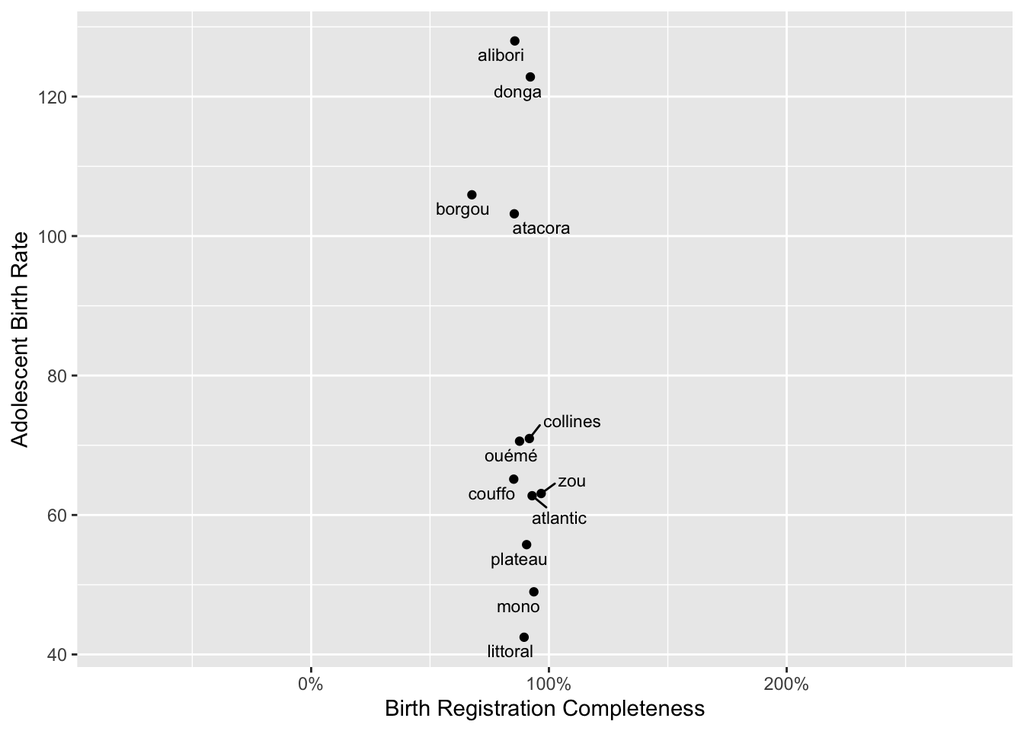

```r
(plot_bj_asfr_reg_10 <-
bj_asfr_reg_10 %>%
filter(agegroup_10 == "15-24") %>%
ggplot(aes(x = birth_reg, y = ASFR)) +
geom_point() +
labs(title =  NULL,
     x = "Birth Registration Completeness", y = "Adolescent Birth Rate",
     color = "Regions") +
scale_x_continuous(labels = scales::percent,
                   expand = c(0.5, 0), limits = c(0,NA)) +
geom_text_repel(size = 3, aes(label = hv024),
          hjust = -0.1, vjust = -0.3, position = position_dodge(width=2),
          color = "black"))
```

```r
bj_chmort <- chmort(bjbr71fl, Class = "v024")
```

```
##
##  The current function calculated Childhood Mortality Rates based on a reference period of 60 months
##  The reference period ended at the time of the interview, in 2018 OR Nov - NA 2017
##  The average reference period is 2015.5
```

```r
bj_chmort <-
bj_chmort %>%
filter( R %in% c(27.92, 20.63, 36.81, 26.76, 33.73, 19.13, 44.20, 14.67, 35.79, 19.05,  53.66, 31.98))

birth_reg_by_region_agegroup_5  <-
U5BCOR_df(data = bjbrirpr71fl, var1 = ~birth_reg, var2 =  ~hv024+agegroup_5) %>%
rename(hv024 = Region)

#creating a matching variable for the fertility rate table
bj_chmort$matching <- paste(bj_chmort$Class)


#reloading women dataset

bjir_asfr <-
read_dta("/Users/ramoudaneorousannou/Downloads/Dhs_data/BJIR71DT/BJIR71FL.DTA")

#calculating the fertility rate
bj_asfr <- fert(bjir_asfr, Indicator = "asfr", Cluster = "v021", Class = "v024")
```

```
##
##  The current function calculated ASFR based on a reference period of 36 months
##  The reference period ended at the time of the interview, in 2018.08 OR Nov - NA 2017
##  The average reference period is 2016.58
```

```r
#creating a matching variable for the fertility rate table
bj_asfr$matching <- paste(bj_asfr$Class)


bj_chmort <- bj_chmort %>%
inner_join(bj_asfr, by = "matching")


bj_chmort
```

| Class.x | R | N.x | WN.x | matching | Class.y | AGE | ASFR | SE | N.y | WN.y | DEFT | RSE | LCI | UCI |
| --- | --- | --- | --- | --- | --- | --- | --- | --- | --- | --- | --- | --- | --- | --- |
| alibori | 27.92 | 1619 | 1809 | alibori | alibori | 15-19 | 162.520 | 10.862 | 1117 | 1244 | 1.100 | 0.067 | 141.230 | 183.810 |
| alibori | 27.92 | 1619 | 1809 | alibori | alibori | 20-24 | 287.625 | 11.690 | 983 | 1114 | 0.972 | 0.041 | 264.713 | 310.537 |
| alibori | 27.92 | 1619 | 1809 | alibori | alibori | 25-29 | 280.378 | 14.187 | 903 | 1027 | 1.142 | 0.051 | 252.572 | 308.185 |
| alibori | 27.92 | 1619 | 1809 | alibori | alibori | 30-34 | 229.856 | 17.688 | 655 | 685 | 1.136 | 0.077 | 195.189 | 264.523 |
| alibori | 27.92 | 1619 | 1809 | alibori | alibori | 35-39 | 162.007 | 15.217 | 481 | 528 | 1.043 | 0.094 | 132.182 | 191.832 |
| alibori | 27.92 | 1619 | 1809 | alibori | alibori | 40-44 | 80.536 | 13.889 | 400 | 439 | 1.068 | 0.172 | 53.314 | 107.758 |
| alibori | 27.92 | 1619 | 1809 | alibori | alibori | 45-49 | 29.476 | 12.116 | 237 | 262 | 1.118 | 0.411 | 5.729 | 53.223 |
| atacora | 20.63 | 1310 | 1208 | atacora | atacora | 15-19 | 135.754 | 13.258 | 912 | 870 | 1.285 | 0.098 | 109.768 | 161.739 |
| atacora | 20.63 | 1310 | 1208 | atacora | atacora | 20-24 | 280.845 | 17.493 | 764 | 721 | 1.348 | 0.062 | 246.559 | 315.131 |
| atacora | 20.63 | 1310 | 1208 | atacora | atacora | 25-29 | 292.035 | 14.456 | 635 | 579 | 0.944 | 0.049 | 263.702 | 320.367 |

[output cut: 81 more lines]

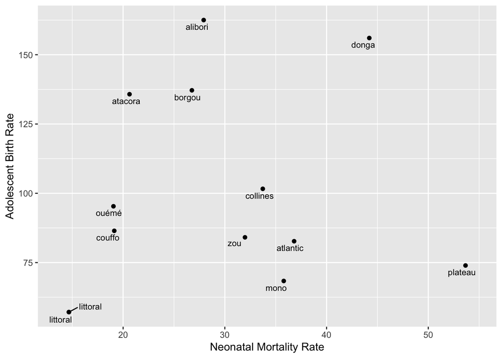

```r
(plot_bj_chmort <-
bj_chmort %>%
filter(AGE == "15-19") %>%
ggplot(aes(x = R, y = ASFR)) +
geom_point() +
labs(title =  NULL,
     x = "Neonatal Mortality Rate", y = "Adolescent Birth Rate",
     color = "Regions") +
geom_text_repel(size = 3, aes(label = matching),
          hjust = -0.1, vjust = -0.3, position = position_dodge(width=2),
          color = "black"))
```